# Regresión Múltiple

Paul Esker

## Antecedentes

Para este ejercio se realizará un análisis de regresión múltiple. En este tipo de ejercio la idea es examinar la forma de una relación más compleja, por ejemplo que la respuesta depende de dos o tres factores diferentes cada uno que contribuya algo a la relación. Esto significa que cada factor explica algo sobre la variabilidad observada en la variable dependiente.

Algunas de las formas de una regresión incluyen:

$Y = \beta_0 + \beta_1{X_1} + \beta_2{X_2} + \epsilon$

$Y = \beta_0 + \beta_1{X_1} + \beta_2{X_2} + \beta_3{X_1}{X_2} + \epsilon$

Algo muy importante tener presente es que en este tipo de análisis el modelo siempre se mejora cuando se agregan factores adicionales. El reto es determinar hasta que punto las mejoras en el modelo “vale la pena”. Es algo que vamos a discutir durante los demás ejemplos del curso.

```r
library(tidyverse)
library(Hmisc)
```

```r
library(corrplot)
library(readr)
library(HH)
library(car)
library(scatterplot3d)
```

## Datos y análisis exploratorio

El conjunto de datos viene de un estudio en donde se midió el número de áfidos de acuerdo a la temperatura promedio y humedad relativa. Los datos pertenecen a lotes de muestreo diferentes y vamos a utilizar la información sobre los lotes para estudiar el comportamiento entre las variables.

La gran pregunta es si hubiese alguna relación entre uno, dos, o más de estos factores. La última parte de la frase anterior significa si existiera alguna interacción entre las dos variables independientes.

```r
lote <- c(1:34)
afidos <- c(61, 77, 87, 93, 98, 100, 104, 118, 102, 74, 63, 43, 27, 19, 14, 23, 30, 25, 67, 40, 6, 21, 18, 23, 42, 56, 60, 59, 82, 89, 77, 102, 108, 97)
temperatura <- c(21, 24.8, 28.3, 26, 27.5, 27.1, 26.8, 29, 28.3, 34, 30.5, 28.3, 30.8, 31, 33.6, 31.8, 31.3, 33.5, 33, 34.5, 34.3, 34.3, 33, 26.5, 32, 27.3, 27.8, 25.8, 25, 18.5, 26, 19, 18, 16.3)
humedad <- c(57,48, 41.5, 56, 58, 31, 36.5, 41, 40, 25, 34, 13, 37, 19, 20, 17, 21, 18.5, 24.5, 16, 6, 26, 21, 26, 28, 24.5, 39, 29, 41, 53.5, 51, 48, 70, 79.5)

afidos_base <- data.frame(lote, afidos, temperatura, humedad)

# Análisis exploratorio
summary(afidos_base)
```

```
##       lote           afidos        temperatura       humedad
##  Min.   : 1.00   Min.   :  6.00   Min.   :16.30   Min.   : 6.00
##  1st Qu.: 9.25   1st Qu.: 27.75   1st Qu.:26.00   1st Qu.:21.88
##  Median :17.50   Median : 62.00   Median :28.30   Median :32.50
##  Mean   :17.50   Mean   : 61.91   Mean   :28.09   Mean   :35.19
##  3rd Qu.:25.75   3rd Qu.: 92.00   3rd Qu.:31.95   3rd Qu.:46.38
##  Max.   :34.00   Max.   :118.00   Max.   :34.50   Max.   :79.50
```

```r
cor(afidos_base[,2:4])
```

```
##                 afidos temperatura    humedad
## afidos       1.0000000  -0.6463022  0.7394570
## temperatura -0.6463022   1.0000000 -0.8313696
## humedad      0.7394570  -0.8313696  1.0000000
```

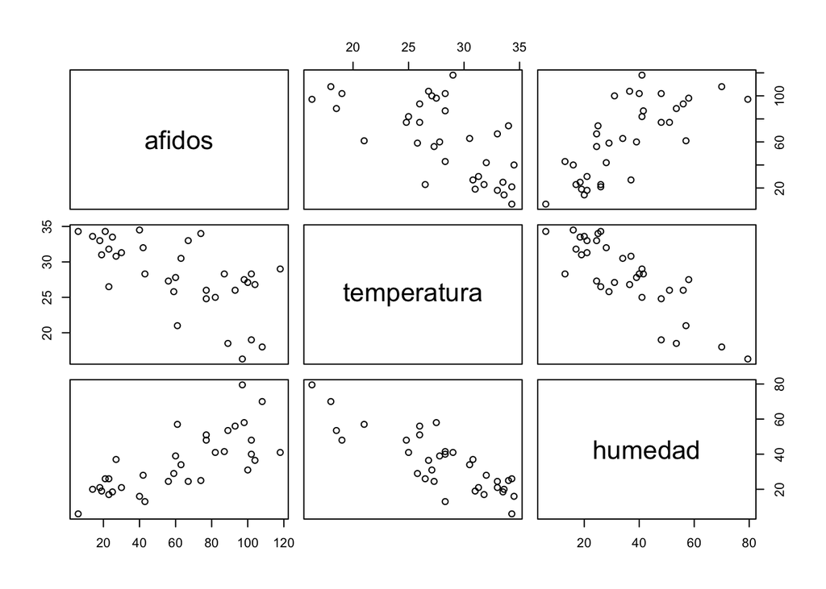

```r
plot(afidos_base[,2:4]) # Matriz de gráficas
pairs(afidos_base[,2:4]) # Otra manera de hacer lo mismo
```

## Regresiones lineales

```r
# Factor = temperatura (X)

modelo1<-with(afidos_base, lm(afidos~temperatura))
anova(modelo1)
```

|  | Df | Sum Sq | Mean Sq | F value | Pr(>F) |
| --- | --- | --- | --- | --- | --- |
| temperatura | 1 | 15194.80 | 15194.7987 | 22.9551 | 3.642997e-05 |
| Residuals | 32 | 21181.94 | 661.9355 | NA | NA |

```r
summary(modelo1)
```

```
##
## Call:
## lm(formula = afidos ~ temperatura)
##
## Residuals:
##     Min      1Q  Median      3Q     Max
## -45.698 -18.111  -3.143  19.477  60.004
##
## Coefficients:
##             Estimate Std. Error t value Pr(>|t|)
## (Intercept) 182.1386    25.4785   7.149 4.10e-08 ***
## temperatura  -4.2808     0.8935  -4.791 3.64e-05 ***
## ---
## Signif. codes:  0 '***' 0.001 '**' 0.01 '*' 0.05 '.' 0.1 ' ' 1
##
## Residual standard error: 25.73 on 32 degrees of freedom
## Multiple R-squared:  0.4177, Adjusted R-squared:  0.3995
## F-statistic: 22.96 on 1 and 32 DF,  p-value: 3.643e-05
```

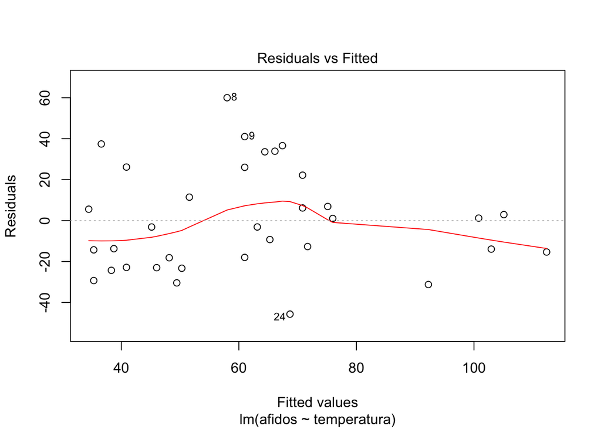

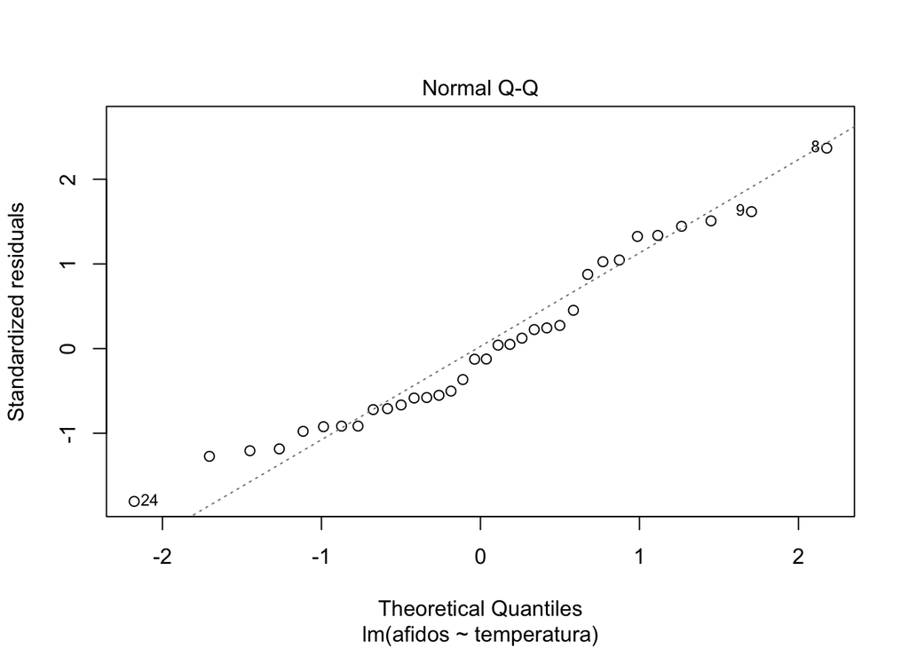

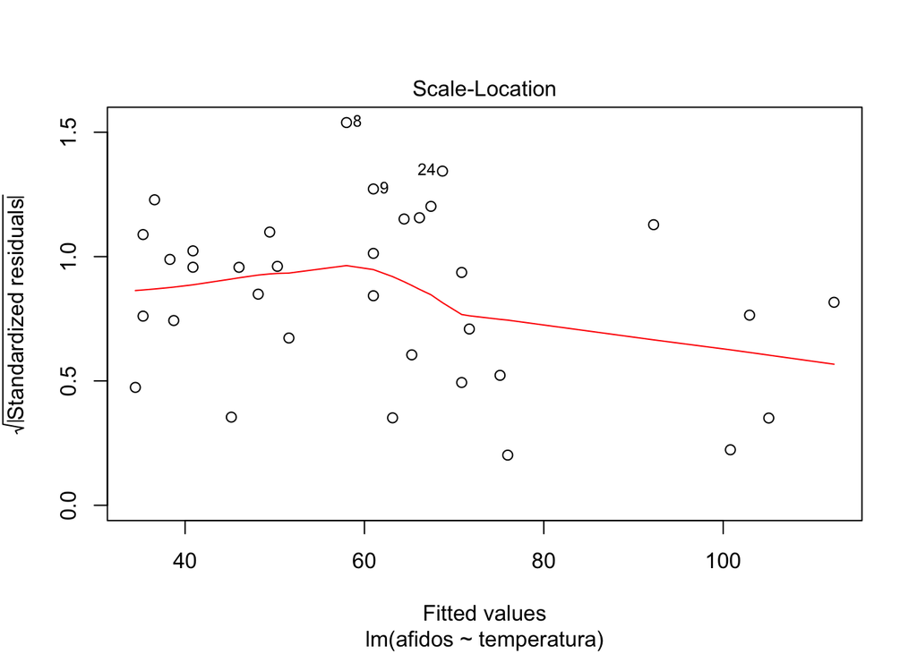

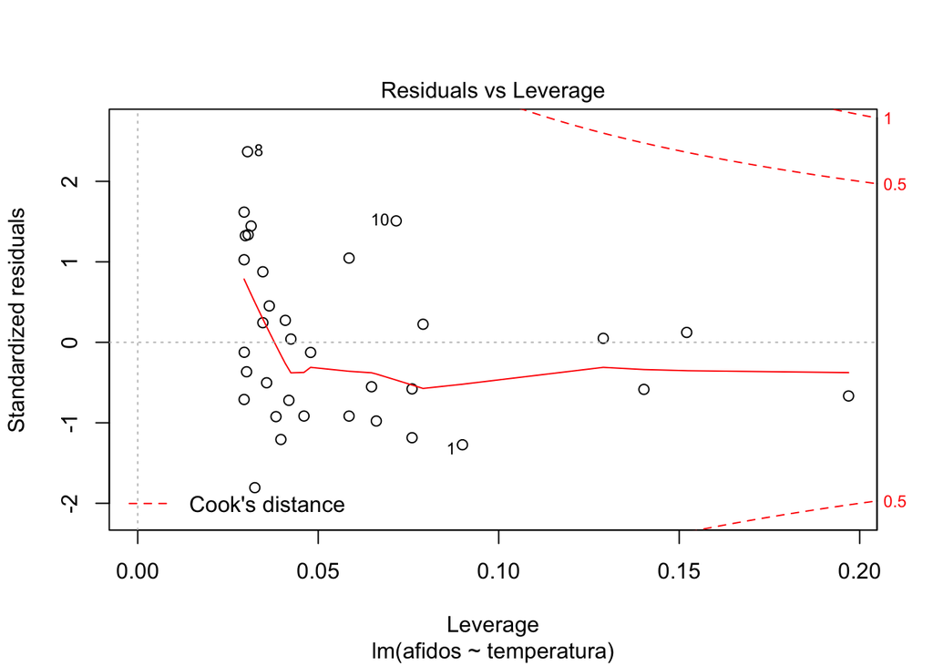

```r
plot(modelo1)
```

```r
# Supuestos = valores, modelo2

rstudent(modelo1)
```

```
##           1           2           3           4           5           6
## -1.28585895  0.04005818  1.02696012  0.87344711  1.34166917  1.35439948
##           7           8           9          10          11          12
##  1.47093718  2.56708773  1.66182645  1.54106791  0.44669460 -0.70426322
##          13          14          15          16          17          18
## -0.92092001 -1.21610745 -0.97682293 -0.91330799 -0.71519631 -0.54584549
##          19          20          21          22          23          24
##  1.04821427  0.22134400 -1.19286546 -0.57242992 -0.91388994 -1.87539948
##          25          26          27          28          29          30
## -0.12367881 -0.36099265 -0.12169500 -0.49651581  0.26909704 -0.57840180
##          31          32          33          34
##  0.24013268  0.04903167  0.12114783 -0.66038629
```

```r
dfbetas(modelo1)
```

```
##     (Intercept)  temperatura
## 1  -0.366682839  0.331661207
## 2   0.005815635 -0.004670407
## 3   0.023305013  0.007772618
## 4   0.089808162 -0.064378045
## 5   0.067723562 -0.027686588
## 6   0.087212625 -0.047068694
## 7   0.110092705 -0.066711426
## 8  -0.004133934  0.082814320
## 9   0.037712163  0.012577648
## 10 -0.276055170  0.328520764
## 11 -0.024068323  0.038160258
## 12 -0.015981987 -0.005330265
## 13  0.059303647 -0.088531881
## 14  0.086856812 -0.125611236
```

[output cut: 20 more lines]

```r
dffits(modelo1)
```

```
##            1            2            3            4            5
## -0.404272806  0.008432063  0.178944815  0.165495030  0.235239322
##            6            7            8            9           10
##  0.240562702  0.264859612  0.454709984  0.289568427  0.427975171
##           11           12           13           14           15
##  0.086872782 -0.122715819 -0.183780341 -0.247127470 -0.259852603
##           16           17           18           19           20
## -0.200671906 -0.149517430 -0.143648162  0.261386769  0.064842854
##           21           22           23           24           25
## -0.342084958 -0.164159053 -0.227891133 -0.343410519 -0.027739070
##           26           27           28           29           30
## -0.063654708 -0.021220776 -0.095548871  0.055563960 -0.233580039
##           31           32           33           34
##  0.045498765  0.018866121  0.051306429 -0.327009697
```

```r
covratio(modelo1)
```

```
##         1         2         3         4         5         6         7
## 1.0553084 1.1126545 1.0268519 1.0514226 0.9810703 0.9797855 0.9612415
##         8         9        10        11        12        13        14
## 0.7474350 0.9256398 0.9902076 1.0917586 1.0636026 1.0497679 1.0108127
##        15        16        17        18        19        20        21
## 1.0738384 1.0592292 1.0763152 1.1177641 1.0556567 1.1533544 1.0541908
##        22        23        24        25        26        27        28
## 1.1291908 1.0732083 0.8882885 1.1180537 1.0895089 1.0969090 1.0876492
##        29        30        31        32        33        34
## 1.1058148 1.2130097 1.0997154 1.2231239 1.2554800 1.2902753
```

```r
cooks.distance(modelo1)
```

```
##            1            2            3            4            5
## 8.008297e-02 3.669472e-05 1.598333e-02 1.379652e-02 2.699386e-02
##            6            7            8            9           10
## 2.819990e-02 3.384457e-02 8.800702e-02 3.973731e-02 8.780865e-02
##           11           12           13           14           15
## 3.870253e-03 7.650078e-03 1.696816e-02 3.008573e-02 3.381010e-02
##           16           17           18           19           20
## 2.023952e-02 1.135101e-02 1.054883e-02 3.405642e-02 2.166690e-03
##           21           22           23           24           25
## 5.774783e-02 1.376327e-02 2.610161e-02 5.466541e-02 3.969427e-04
##           26           27           28           29           30
## 2.082560e-03 2.323129e-04 4.674868e-03 1.589759e-03 2.785916e-02
##           31           32           33           34
## 1.066474e-03 1.836918e-04 1.357989e-03 5.442676e-02
```

```r
# Factor = humedad (X)

modelo2<-with(afidos_base, lm(afidos~humedad))
anova(modelo2)
```

|  | Df | Sum Sq | Mean Sq | F value | Pr(>F) |
| --- | --- | --- | --- | --- | --- |
| humedad | 1 | 19890.68 | 19890.6770 | 38.60848 | 5.857452e-07 |
| Residuals | 32 | 16486.06 | 515.1893 | NA | NA |

```r
summary(modelo2)
```

```
##
## Call:
## lm(formula = afidos ~ humedad)
##
## Residuals:
##    Min     1Q Median     3Q    Max
## -37.53 -13.44  -1.43  12.82  47.68
##
## Coefficients:
##             Estimate Std. Error t value Pr(>|t|)
## (Intercept)  10.9787     9.0744   1.210    0.235
## humedad       1.4473     0.2329   6.214 5.86e-07 ***
## ---
## Signif. codes:  0 '***' 0.001 '**' 0.01 '*' 0.05 '.' 0.1 ' ' 1
##
## Residual standard error: 22.7 on 32 degrees of freedom
## Multiple R-squared:  0.5468, Adjusted R-squared:  0.5326
## F-statistic: 38.61 on 1 and 32 DF,  p-value: 5.857e-07
```

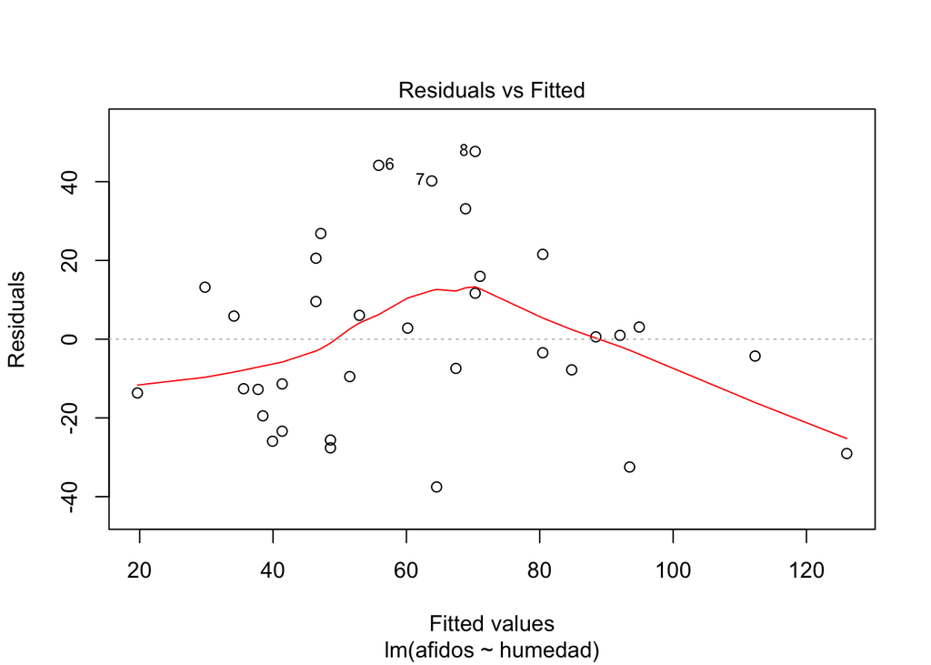

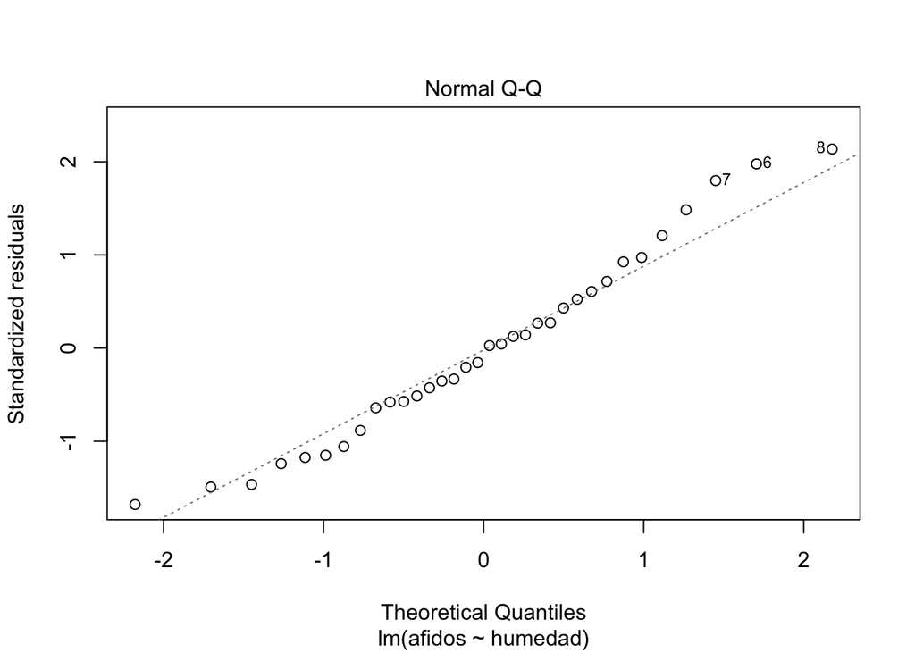

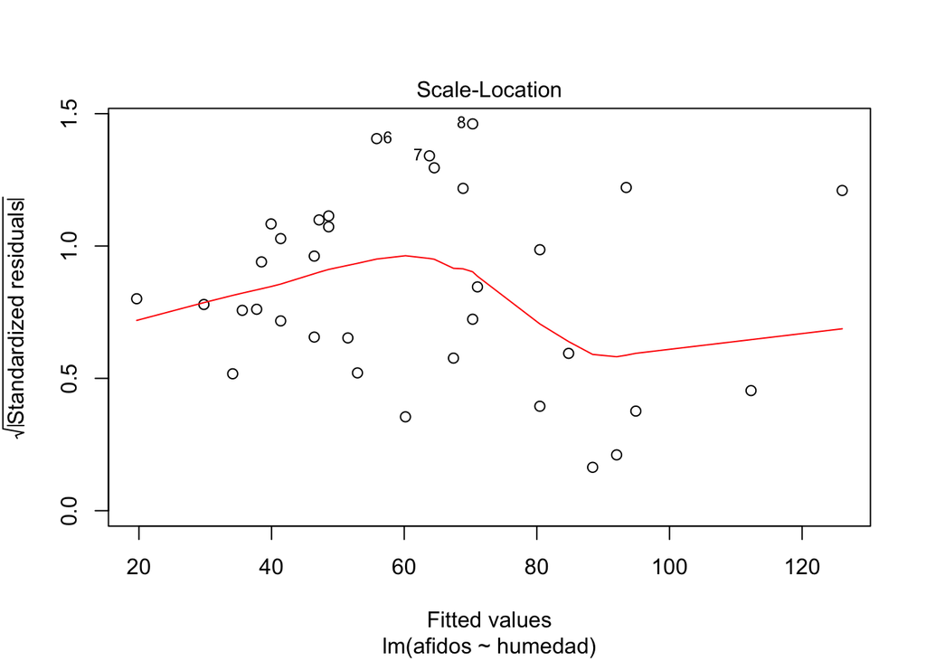

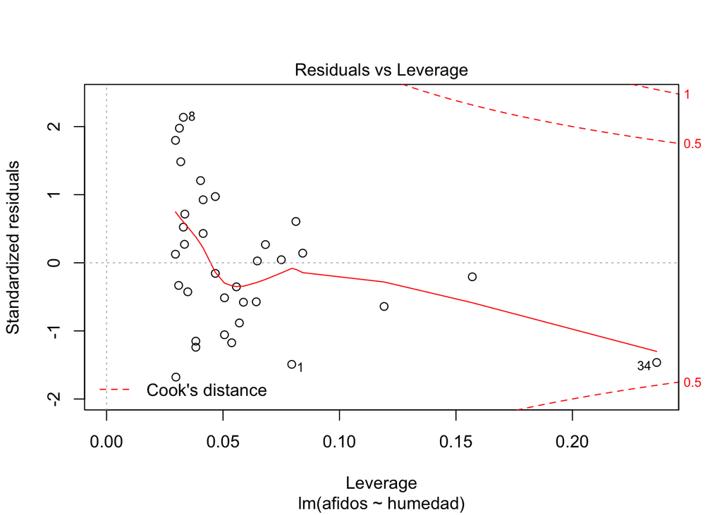

```r
plot(modelo2)
```

```r
# Supuestos = valores, modelo2

rstudent(modelo2)
```

```
##           1           2           3           4           5           6
## -1.52166116 -0.15329366  0.70958337  0.04378704  0.13944816  2.07616739
##           7           8           9          10          11          12
##  1.86604477  2.27067980  1.51293060  1.21600986  0.12382267  0.60092052
##          13          14          15          16          17          18
## -1.73010695 -0.88059890 -1.18139920 -0.56699356 -0.50823171 -0.57307681
##          19          20          21          22          23          24
##  0.92313524  0.26372262 -0.63535605 -1.25128763 -1.05882161 -1.15657354
##          25          26          27          28          29          30
## -0.42068829  0.42473282 -0.32760978  0.26710592  0.51730586  0.02642984
##          31          32          33          34
## -0.34840648  0.97153856 -0.20281479 -1.49172395
```

```r
dfbetas(modelo2)
```

```
##     (Intercept)      humedad
## 1   0.203962802 -0.354960067
## 2   0.007091915 -0.020637509
## 3   0.010888321  0.046732070
## 4  -0.005432893  0.009722237
## 5  -0.020090271  0.034108001
## 6   0.237139151 -0.090726882
## 7   0.116375070  0.025442918
## 8   0.045533868  0.137646115
## 9   0.044574968  0.075879906
## 10  0.208590411 -0.129821254
## 11  0.010635007 -0.001536502
## 12  0.175091541 -0.142772652
## 13 -0.099765368 -0.032603908
## 14 -0.202822717  0.150676741
```

[output cut: 20 more lines]

```r
dffits(modelo2)
```

```
##            1            2            3            4            5
## -0.447191192 -0.033924951  0.132317421  0.012469416  0.042283274
##            6            7            8            9           10
##  0.372962648  0.325861688  0.419240517  0.274398674  0.249344653
##           11           12           13           14           15
##  0.021611110  0.178729735 -0.302985776 -0.216541182 -0.281470975
##           16           17           18           19           20
## -0.148585846 -0.117356163 -0.143175941  0.191962176  0.071346658
##           21           22           23           24           25
## -0.233677243 -0.249738808 -0.244493286 -0.230835253 -0.079949336
##           26           27           28           29           30
##  0.088321443 -0.058538076  0.049688881  0.095511299  0.006952189
##           31           32           33           34
## -0.084642540  0.215008230 -0.087530558 -0.829472811
```

```r
covratio(modelo2)
```

```
##         1         2         3         4         5         6         7
## 1.0022713 1.1160516 1.0676446 1.1518269 1.1620673 0.8477864 0.8874781
##         8         9        10        11        12        13        14
## 0.8100232 0.9544553 1.0115565 1.0969300 1.1332631 0.9133416 1.0755087
##        15        16        17        18        19        20        21
## 1.0311057 1.1154780 1.1038994 1.1084567 1.0529470 1.1384310 1.1787935
##        22        23        24        25        26        27        28
## 1.0040208 1.0453923 1.0182323 1.0915424 1.0988072 1.0920026 1.0973744
##        29        30        31        32        33        34
## 1.0831002 1.1392331 1.1196610 1.0526653 1.2606798 1.2144142
```

```r
cooks.distance(modelo2)
```

```
##            1            2            3            4            5
## 9.604190e-02 5.935641e-04 8.891911e-03 8.024605e-05 9.221958e-04
##            6            7            8            9           10
## 6.302998e-02 4.927114e-02 7.777970e-02 3.618960e-02 3.062822e-02
##           11           12           13           14           15
## 2.409338e-04 1.629755e-02 4.320873e-02 2.361072e-02 3.912909e-02
##           16           17           18           19           20
## 1.127801e-02 7.049632e-03 1.046940e-02 1.851025e-02 2.621394e-03
##           21           22           23           24           25
## 2.782097e-02 3.064301e-02 2.977580e-02 2.636426e-02 3.280316e-03
##           26           27           28           29           30
## 4.002862e-03 1.762520e-03 1.271389e-03 4.668043e-03 2.494547e-05
##           31           32           33           34
## 3.683311e-03 2.315487e-02 3.949133e-03 3.313265e-01
```

## Regresión múltiple aditiva

La forma de este modelo es de:

$$áfidos = intercepto + temperatura + humedad + error$$

```r
modelo3<-with(afidos_base, lm(afidos~temperatura+humedad))
anova(modelo3)
```

|  | Df | Sum Sq | Mean Sq | F value | Pr(>F) |
| --- | --- | --- | --- | --- | --- |
| temperatura | 1 | 15194.799 | 15194.7987 | 28.776477 | 7.553738e-06 |
| humedad | 1 | 4813.054 | 4813.0542 | 9.115141 | 5.038124e-03 |
| Residuals | 31 | 16368.882 | 528.0285 | NA | NA |

```r
summary(modelo3)
```

```
##
## Call:
## lm(formula = afidos ~ temperatura + humedad)
##
## Residuals:
##     Min      1Q  Median      3Q     Max
## -35.393 -14.006  -3.198  10.335  49.265
##
## Coefficients:
##             Estimate Std. Error t value Pr(>|t|)
## (Intercept)  35.8255    53.5388   0.669  0.50835
## temperatura  -0.6765     1.4360  -0.471  0.64089
## humedad       1.2811     0.4243   3.019  0.00504 **
## ---
## Signif. codes:  0 '***' 0.001 '**' 0.01 '*' 0.05 '.' 0.1 ' ' 1
##
## Residual standard error: 22.98 on 31 degrees of freedom
## Multiple R-squared:   0.55,  Adjusted R-squared:  0.521
## F-statistic: 18.95 on 2 and 31 DF,  p-value: 4.212e-06
```

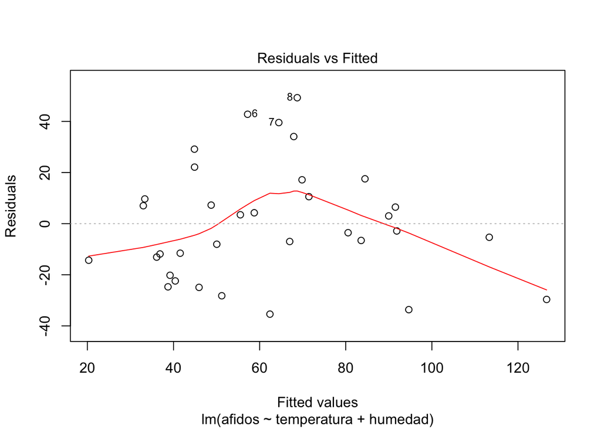

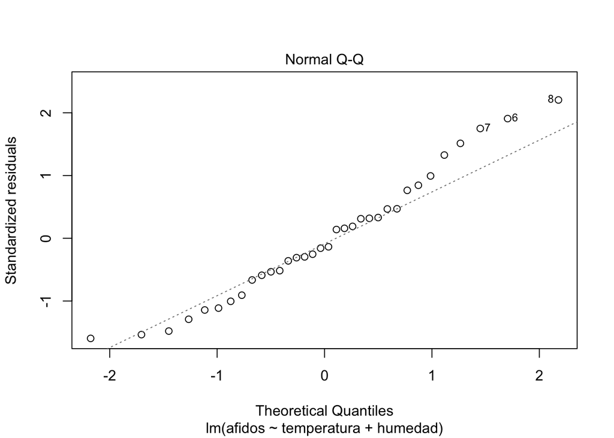

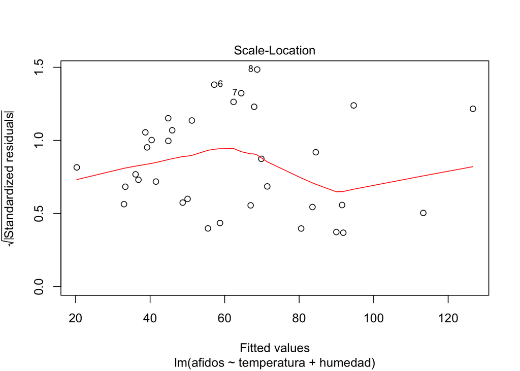

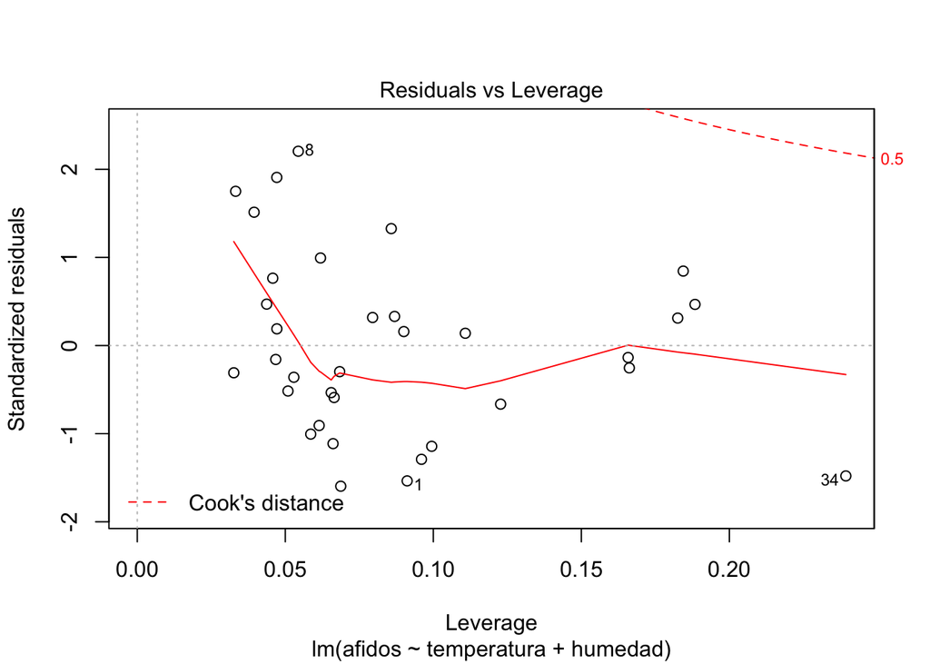

```r
plot(modelo3)
```

## Visualizando las relaciones para un modelo más complejo

Todavía no está totalmente claro si el modelo aditivo con los dos factores es mejor. Antes de meternos a otra regresión primero vamos a volver a visualizar las relaciones para poder tratar de comprender mejor lo que está ocurriendo. La razón de hacer esta pausa en el análisis es que nos intersa saber si hubiese algunas obervaciones intersantes o si la relación entre el número de áfidos con los dos factores tiene alguna interacción, es decir si los dos factores independientes interactuan de alguna manera.

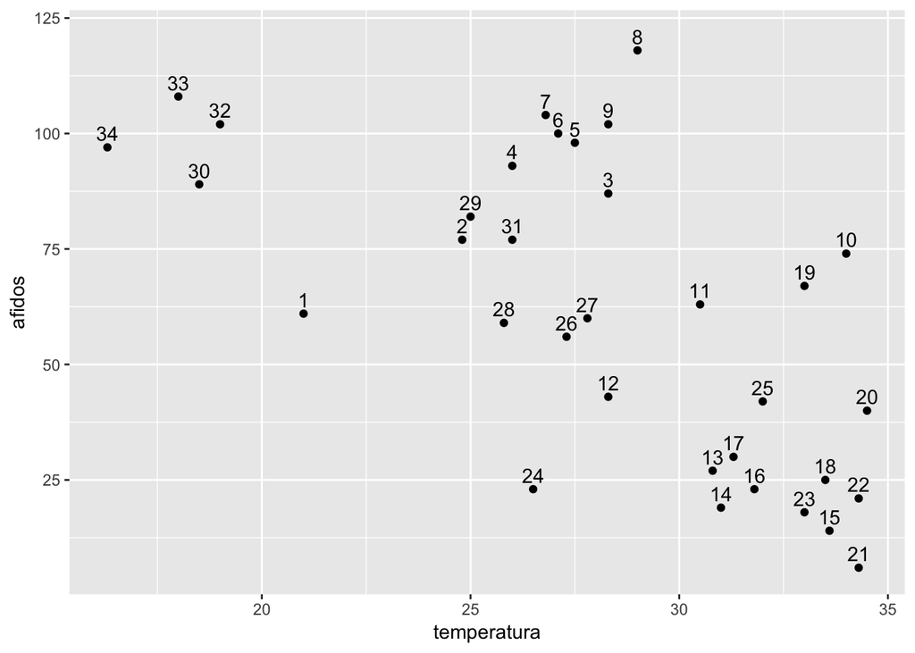

```r
# Considerando el factor de temperatura, se agrega al gráfico la información sobre los lotes
temp <- ggplot(afidos_base, aes(x=temperatura, y=afidos, label=lote))
temp + geom_point() + geom_text(hjust=0.5, nudge_y=3) #Parece que algunos lotes están relacionados, por ejemplo: 30, 32, 33, 34; también los de 3 a 9
```

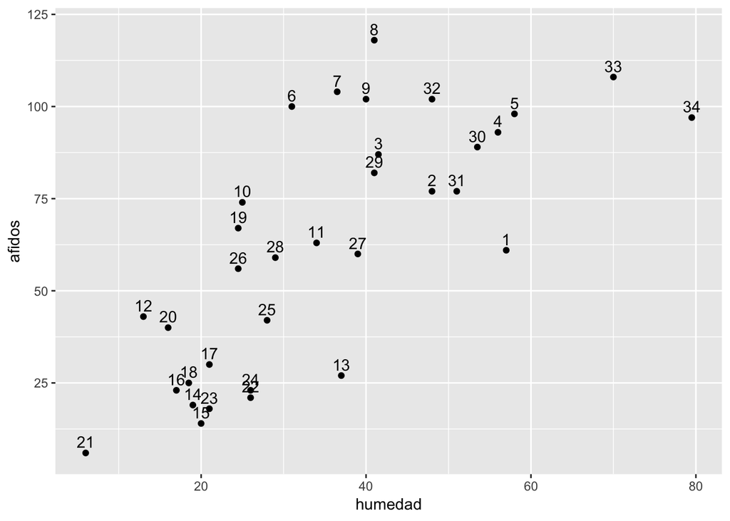

```r
# Considerando el factor de humedad, se agrega al gráfico la información sobre los lotes
temp2 <- ggplot(afidos_base, aes(x=humedad, y=afidos, label=lote))
temp2 + geom_point() + geom_text(hjust=0.5, nudge_y=3) #La agrupación se ve un poco diferente: 6 a 9, sí; 14 a 18 (más algunos otros)
```

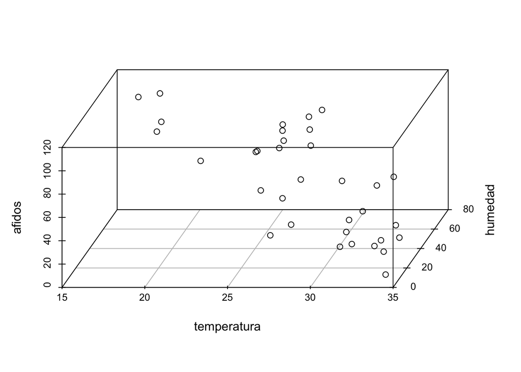

```r
# Y en 3-dimensiones? Esto viene del paquete *scatterplot3d*

with(afidos_base, scatterplot3d(temperatura, humedad, afidos, angle=75)) # Vamos a dejar las etiquetas por el momento
```

## Regresión múltiple con interacción

Debido a que parece que las relaciones entre los números de áfidos y los factores de temperatura y de humedad son diferentes vamos a explorar un modelo que contiene la interacción entre estos dos factores. Biológicamente hay que pensar en lo que significa esta relación pero por el momento la idea es ver si se puede mejorar el ajuste del modelo.

```r
modelo4 <- with(afidos_base, lm(afidos ~ temperatura + humedad + temperatura:humedad))

anova(modelo4)
```

|  | Df | Sum Sq | Mean Sq | F value | Pr(>F) |
| --- | --- | --- | --- | --- | --- |
| temperatura | 1 | 15194.799 | 15194.7987 | 33.506001 | 2.522089e-06 |
| humedad | 1 | 4813.054 | 4813.0542 | 10.613250 | 2.789073e-03 |
| temperatura:humedad | 1 | 2764.037 | 2764.0372 | 6.094969 | 1.947433e-02 |
| Residuals | 30 | 13604.845 | 453.4948 | NA | NA |

```r
summary(modelo4) # El R^2 mejoró. Hay que ver este resultado considerando los demás modelos.
```

```
##
## Call:
## lm(formula = afidos ~ temperatura + humedad + temperatura:humedad)
##
## Residuals:
##    Min     1Q Median     3Q    Max
## -41.13 -12.87  -2.02  10.25  41.75
##
## Coefficients:
##                      Estimate Std. Error t value Pr(>|t|)
## (Intercept)         150.70989   68.02395   2.216   0.0345 *
## temperatura          -4.72276    2.11121  -2.237   0.0329 *
## humedad              -1.29670    1.11576  -1.162   0.2543
## temperatura:humedad   0.09728    0.03940   2.469   0.0195 *
## ---
## Signif. codes:  0 '***' 0.001 '**' 0.01 '*' 0.05 '.' 0.1 ' ' 1
##
## Residual standard error: 21.3 on 30 degrees of freedom
## Multiple R-squared:  0.626,  Adjusted R-squared:  0.5886
## F-statistic: 16.74 on 3 and 30 DF,  p-value: 1.414e-06
```

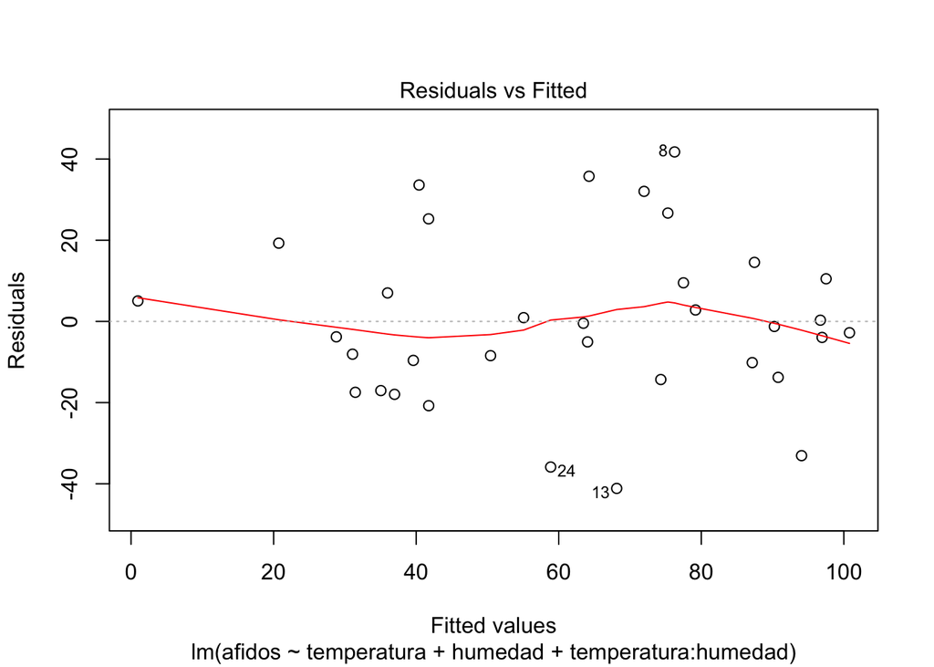

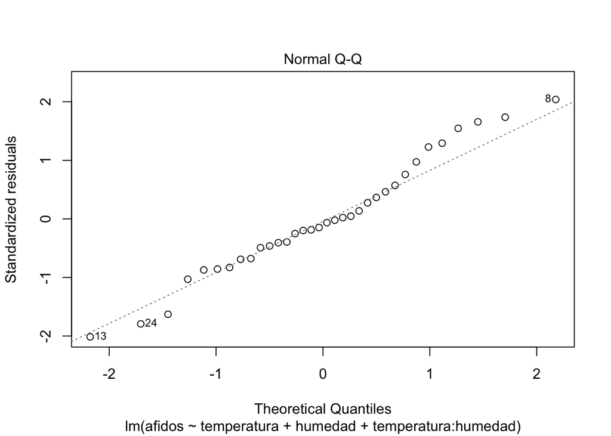

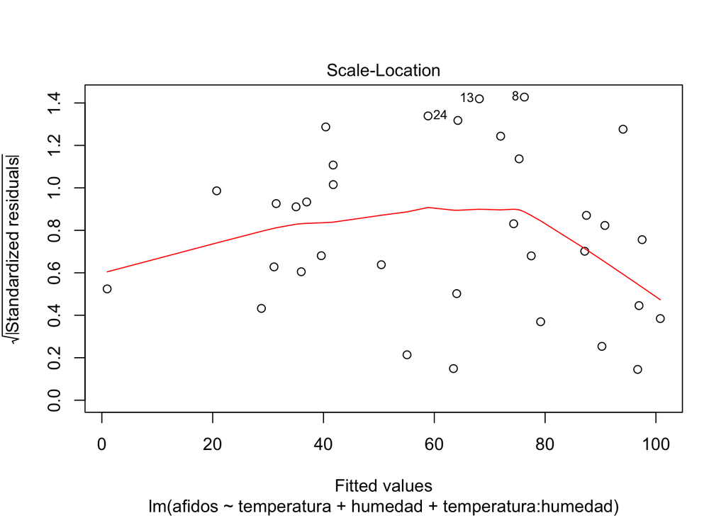

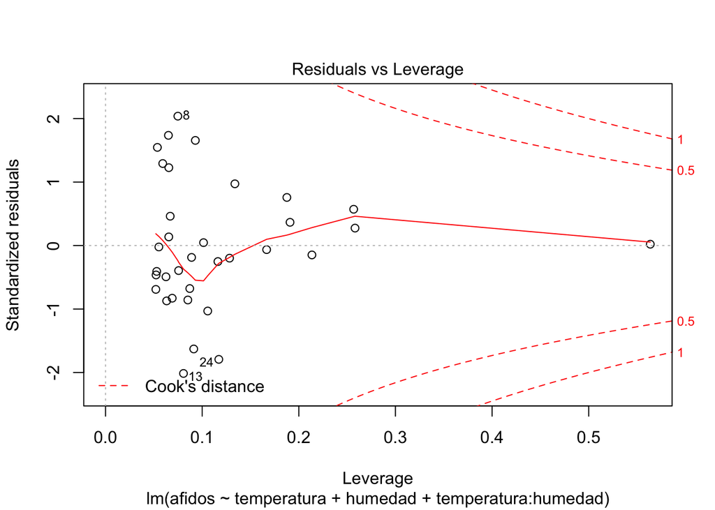

```r
plot(modelo4)
```

```r
# Comparaciones entre los diferentes modelos para tomar una decisión
anova(modelo1, modelo3) # modelo 3 fue mejor (tenía el factor de humedad agregado)
```

|  | Res.Df | RSS | Df | Sum of Sq | F | Pr(>F) |
| --- | --- | --- | --- | --- | --- | --- |
| 1 | 32 | 21181.94 | NA | NA | NA | NA |
| 2 | 31 | 16368.88 | 1 | 4813.054 | 9.115141 | 0.005038124 |

```r
anova(modelo2, modelo3) # modelo 2 fue mejor (sólo con el factor de humedad)
```

|  | Res.Df | RSS | Df | Sum of Sq | F | Pr(>F) |
| --- | --- | --- | --- | --- | --- | --- |
| 1 | 32 | 16486.06 | NA | NA | NA | NA |
| 2 | 31 | 16368.88 | 1 | 117.1759 | 0.221912 | 0.6408852 |

```r
anova(modelo2, modelo4) # puede ser que la interacción mejoró el modelo
```

|  | Res.Df | RSS | Df | Sum of Sq | F | Pr(>F) |
| --- | --- | --- | --- | --- | --- | --- |
| 1 | 32 | 16486.06 | NA | NA | NA | NA |
| 2 | 30 | 13604.85 | 2 | 2881.213 | 3.176677 | 0.05605981 |

```r
anova(modelo3, modelo4) # la intearcción mejoró el modelo
```

|  | Res.Df | RSS | Df | Sum of Sq | F | Pr(>F) |
| --- | --- | --- | --- | --- | --- | --- |
| 1 | 31 | 16368.88 | NA | NA | NA | NA |
| 2 | 30 | 13604.85 | 1 | 2764.037 | 6.094969 | 0.01947433 |

```r
# Todavía se puede revisar los supuestos en más detalle para tomar la decisión final
```

## Predicciones

Para cerrar la discusión sobre los modelos de regresión múltiple vamos a realizar algunas predicciones de acuerdo al modelo 4.

```r
# Considerando los valores promedios de temperatura y de humedad
mean(temperatura)
```

```
## [1] 28.08529
```

```r
mean(humedad)
```

```
## [1] 35.19118
```

```r
observacion <- data.frame(temperatura=mean(temperatura), humedad=mean(humedad))

predict(object=modelo4, newdata=observacion, interval="confidence")
```

```
##        fit      lwr      upr
## 1 68.58645 59.30643 77.86646
```

```r
predict(object=modelo4, newdata=observacion, interval="predict")
```

```
##        fit      lwr      upr
## 1 68.58645 24.11635 113.0565
```

```r
# Para todas las observaciones
intervalos<-predict(modelo4, interval="confidence")
intervalos
```

```
##            fit        lwr       upr
## 1   94.0665692  80.927158 107.20598
## 2   87.1482874  76.271599  98.02498
## 3   77.4955105  66.245093  88.74593
## 4   96.9454425  81.365016 112.52587
## 5  100.7900752  80.691122 120.88903
## 6   64.2519748  53.158443  75.34551
## 7   71.9715847  61.898562  82.04461
## 8   76.2533767  64.356209  88.15054
## 9   75.3109441  64.730640  85.89125
## 10  40.4082060  27.149656  53.66676
## 11  63.4592842  53.244672  73.67390
## 12  35.9887485  16.985340  54.99216
## 13  68.1334763  55.782306  80.48465
## 14  36.9661205  26.029726  47.90252
```

[output cut: 20 more lines]

```r
predicciones<-predict(modelo4, interval="predict")
predicciones
```

```
##            fit        lwr       upr
## 1   94.0665692  48.634034 139.49910
## 2   87.1482874  42.317791 131.97878
## 3   77.4955105  32.572877 122.41814
## 4   96.9454425  50.747815 143.14307
## 5  100.7900752  52.879335 148.70082
## 6   64.2519748  19.368375 109.13557
## 7   71.9715847  27.329263 116.61391
## 8   76.2533767  31.164423 121.34233
## 9   75.3109441  30.551432 120.07046
## 10  40.4082060  -5.058928  85.87534
## 11  63.4592842  18.784802 108.13377
## 12  35.9887485 -11.472822  83.45032
## 13  68.1334763  22.922609 113.34434
## 14  36.9661205  -7.878900  81.81114
```

[output cut: 20 more lines]

## Resumen

El objetivo de este ejercio fue dar una introducción de regresión múltiple cuando hay una serie de variables independientes que pueden explicar aspectos diferentes de la variabilidad observada en la variable dependiente. También al pensar de tal manera esto le proporciona una avenida de considerar las interacciones escondidas entre las diversas variables medidas en muchas de nuestras investigaciones, un concepto importante para análisis estadísticos más complejos o de los métodos multivariantes.